# Weather Exploratory Data Analysis

davegoblue

5/27/2020

## Background

The file ‘WeatherDownloads_202005_v002.Rmd’ contains code for dowloading and processing historical weather data as contained in METAR archives hosted by Iowa State University.

Data have been dowloaded and processed for several stations (airports) and years, with .rds files saved in “./RInputFiles/ProcessedMETAR”.

This module will perform exploratory data analysis on the processed weather files.

#### *Data Availability*

Each processed data file contains one year of hourly weather data for one station. Files are saved as ‘./RInputFiles/ProcessedMETAR/metar_kxxx_yyyy.rds’ where xxx is the three-digit airport code and yyyy is the four-digit year.

Each file contains the following variables:

- METAR (chr) - the extracted portion of the METAR based on a regex string
- WindDir (chr) - the previaling wind direction in degrees, stored as a character since ‘VRB’ means variable
- WindSpeed (int) - the prevailing wind speed in knots
- WindGust (dbl) - the wind gust speed in knots (NA if there is no recorded wind gust at that hour)
- Dummy (chr) - artifact, always a blank space
- Visibility (dbl) - surface visibility in statute miles
- TempC (int) - temperature in degrees Celsius
- DewC (int) - dew point in degrees Celsius
- Altimeter (int) - altimeter in hundredths of inches of mercury (e.g., 29.87 inHg is stored as 2987)
- SLP (int) - the raw sea-level-pressure reading from the METAR
- FahrC (chr) - the raw temperature string pulled from the METAR (Tttttdddd) where tttt is the Fahrenheit temperature recorded in Celsius and dddd is the Fahrenheit dew point recorded in Celsius
- dtime (dttm) - the date-time associated with the observation
- origMETAR (chr) - the full METAR associated with the observation
- TempF (dbl) - the Fahrenheit temperature associated with converting FahrC to Fahrenheit
- DewF (dbl) - the Fahrenheit dew point associated with converting FahrC to Fahrenheit
- modSLP (dbl) - Sea-Level Pressure (SLP), adjusted to reflect that SLP is recorded as 0-1000 but reflects data that are 950-1050
- nSKC (int) - number of times ‘SKC’ (human-confirmed cloud-free) is recorded in the observation (should be 0 or 1)
- nCLR (int) - number of times ‘CLR’ (austomated-sensor cloud-free) is recorded in the observation (should be 0 or 1, and should never have both nSKC>0 and nCLR>0)
- cloudn (chr) - the nth cloud layer recorded in the METAR (layers begin with FEW, SCT, BKN, OVC or VV)
- cTypen (chr) - the cloud type of the nth cloud layer (FEW, BKN, SCT, OVC, or VV)
- cLeveln (dbl) - the cloud height in feet of the nth cloud layer
- wType (fct) - highest level of obscuration recorded in the METAR (VV > OVC > BKN > SCT > FEW > CLR/SKC)
- year (dbl) - year of the observation
- monthint (dbl) - month of the observation as a number (e.g., 6=June)
- month (fct) - month of the observation as three-character abbreviation, saved as a factor (e.g., Jun=June)
- day (int) - day of the month of the observation

#### *Base Functions Available*

There are several functions available for analysis:

- plotCountsByMetric() - bar plots for counts by variable
- plotNumCor() - plot two numeric variables against each other
- plotFactorNumeric() - boxplot a numeric variable against a factor variable
- corMETAR() - correlations between METAR variables
- lmMETAR() - linear regression modeling for METAR variables
- basicWindPlots() - plot wind speed and direction
- getWindDirGroup() - convert wind direction to a grouping (e.g., N for 320-360-40)
- consolidatePlotWind() - show frequency plots of wind direction, city, and month

The tidyverse library is loaded and the 2016 Detroit data is read in to show examples of the functions:

```r
library(tidyverse)
kdtw_2016 <- readRDS("./RInputFiles/ProcessedMETAR/metar_kdtw_2016.rds")
```

A variable mapping is created to allow for better readable variable names:

```r
varMapper <- c(WindDir="Wind Direction (degrees)",
               WindSpeed="Wind Speed (kts)",
               Visibility="Visibility (SM)",
               TempC="Temperature (C)",
               DewC="Dew Point (C)",
               Altimeter="Altimeter - Hundredths of Inches of Mercury",
               modSLP="Sea-Level Pressure (hPa)",
               TempF="Temperature (F)",
               DewF="Dew Point (F)",
               cType1="First Cloud Layer Type",
               month="Month",
               wType="Greatest Sky Obscuration"
               )
```

The function plotCountsByMetric() produces bar plots for counts by variable:

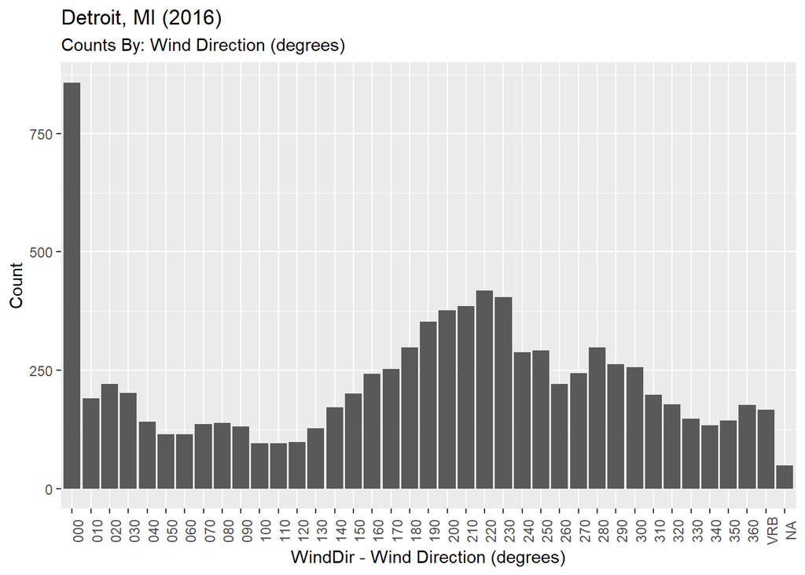

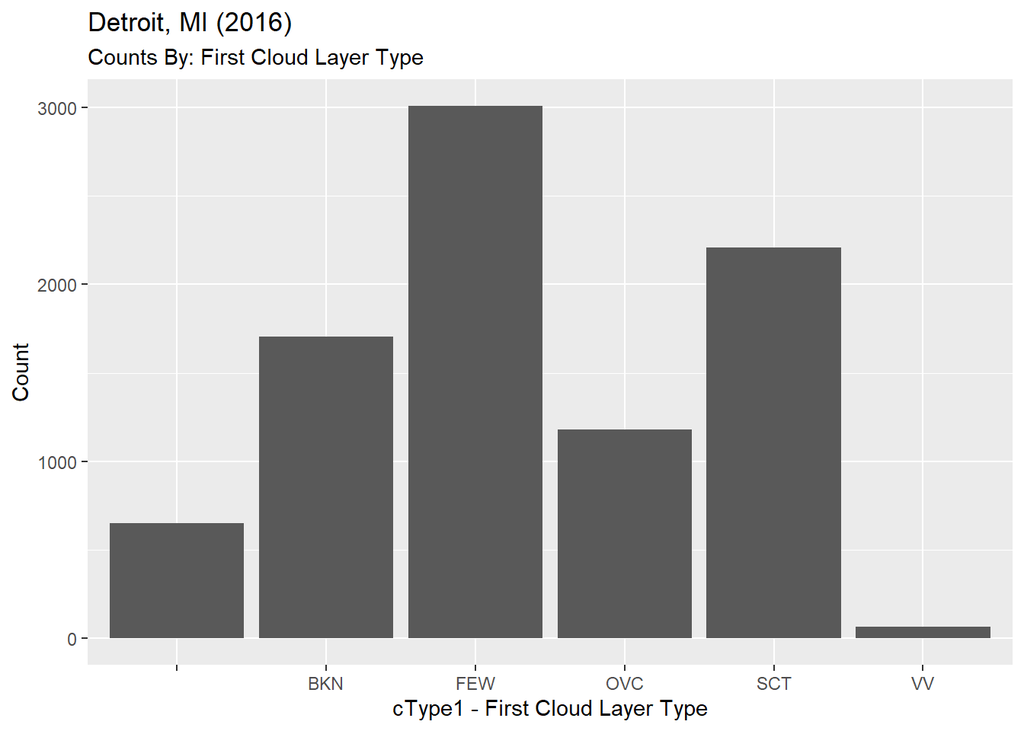

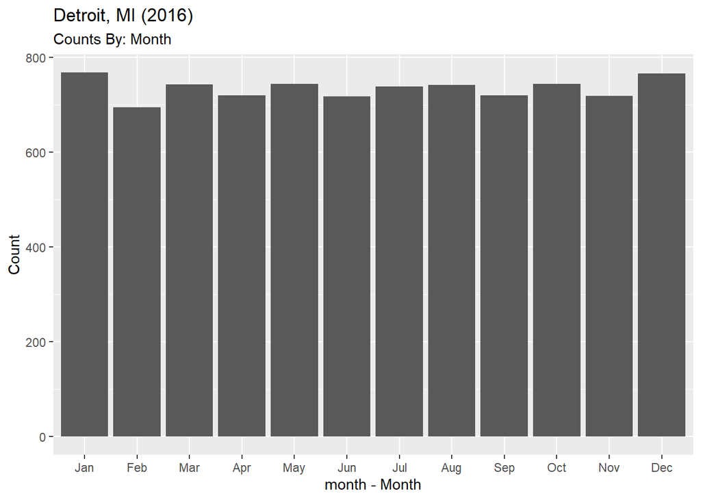

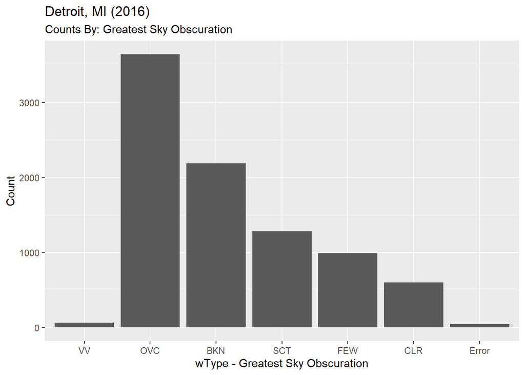

```r
# Helper function for generating plots by key variables
plotcountsByMetric <- function(df, mets, title="", rotateOn=20, mapper=varMapper) {

    # Plot of counts by key metric
    for (x in mets) {
        dat <- df %>%
            group_by_at(vars(all_of(x))) %>%
            summarize(n=n())
        p <- dat %>%
            ggplot(aes_string(x=x, y="n")) +
            geom_col() +
            labs(title=title,
                 subtitle=paste0("Counts By: ", mapper[x]),
                 x=paste0(x, " - ", mapper[x]),
                 y="Count"
                 )
        if (nrow(dat) >= rotateOn) {
            p <- p + theme(axis.text.x=element_text(angle=90))
        }
        print(p)
    }
}

# Example for Detroit 2016 - using WindDir, cType1, month, wType
plotcountsByMetric(kdtw_2016,
                   mets=c("WindDir", "cType1", "month", "wType"),
                   title="Detroit, MI (2016)"
                   )
```

The function plotNumCor() plots two numeric variables against one another:

```
##
## Dropping 1 rows with 49 observations due to NA
```

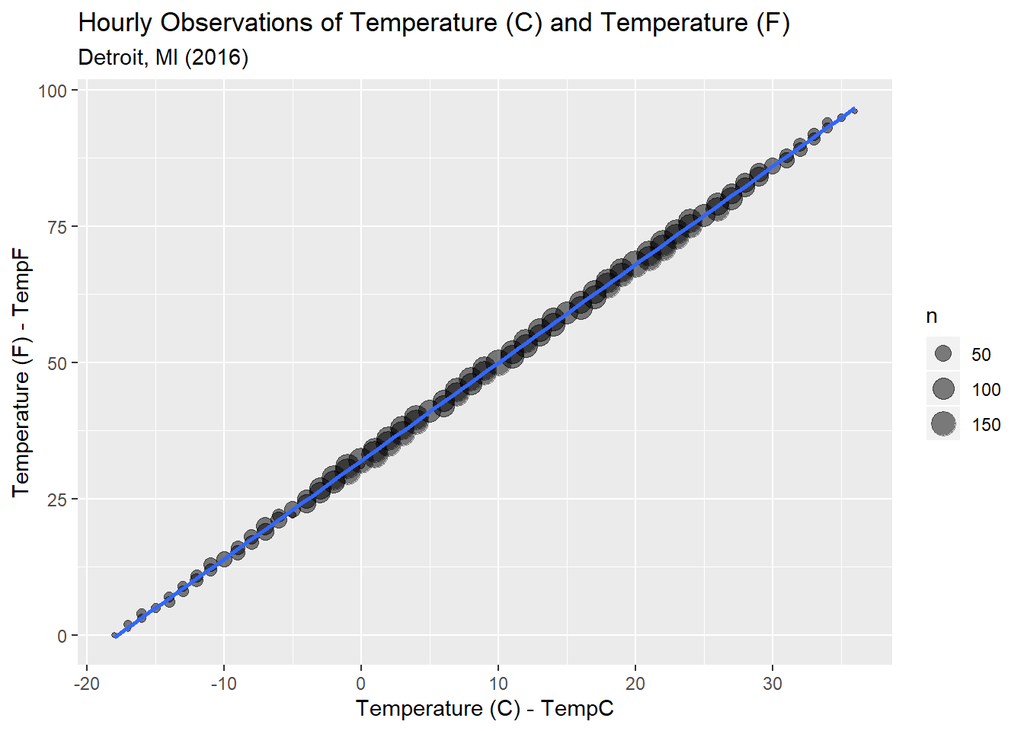

```r
# Create a function for plotting two variables against each other
plotNumCor <- function(met,
                       var1,
                       var2,
                       title=NULL,
                       subT="",
                       dropNA=TRUE,
                       diagnose=FALSE,
                       mapper=varMapper
                       ) {

    # Create the title if not passed
    if (is.null(title)) {
        title <- paste0("Hourly Observations of ", mapper[var1], " and ", mapper[var2])
    }

    # Pull the counts by var1-var2
    dat <- met %>%
        group_by_at(vars(all_of(c(var1, var2)))) %>%
        summarize(n=n())

    # If NA requested to be excluded, remove anything with NA
    if (dropNA) {
        nOrig <- nrow(dat)
        sumOrig <- sum(dat$n)
        dat <- dat %>%
            filter_all(all_vars(!is.na(.)))
        if (diagnose) {
            cat("\nDropping", nOrig-nrow(dat), "rows", "with", sumOrig-sum(dat$n), "observations due to NA\n")
        }
    }

    p <- dat %>%
        ggplot(aes_string(x=var1, y=var2)) +
        geom_point(alpha=0.5, aes_string(size="n")) +
        geom_smooth(method="lm", aes_string(weight="n")) +
        labs(x=paste0(mapper[var1], " - ", var1),
             y=paste0(mapper[var2], " - ", var2),
             title=title,
             subtitle=subT
             )

    print(p)
}

# Example for Detroit 2016 - using TempC and TempF
plotNumCor(kdtw_2016, var1="TempC", var2="TempF", subT="Detroit, MI (2016)", diagnose=TRUE)
```

```
##
## Dropping 1 rows with 49 observations due to NA
```

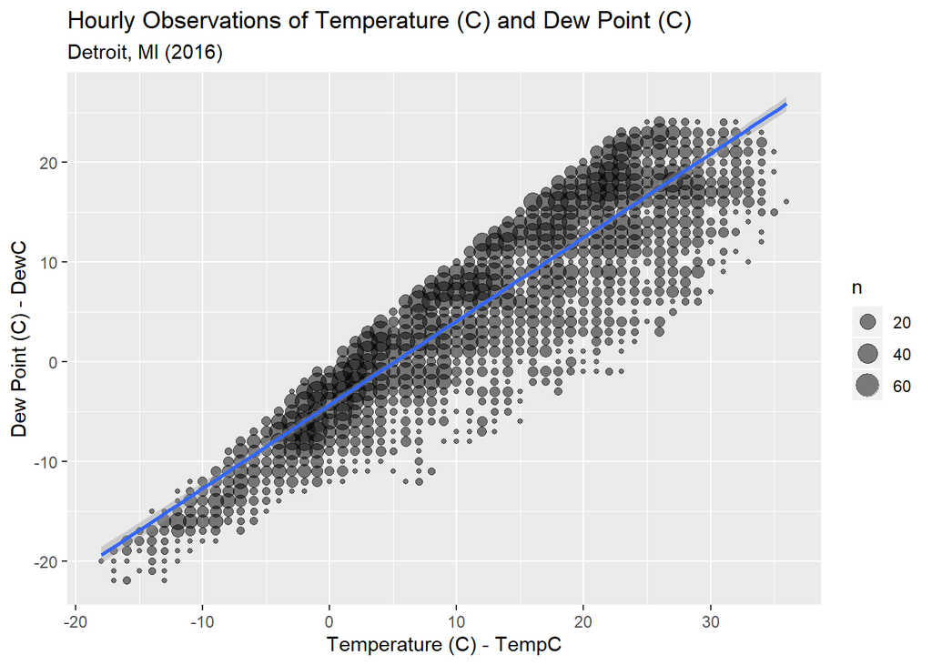

```r
# Example for Detroit 2016 - using TempC and DewC
plotNumCor(kdtw_2016, var1="TempC", var2="DewC", subT="Detroit, MI (2016)", diagnose=TRUE)
```

```
##
## Dropping 1 rows with 49 observations due to NA
```

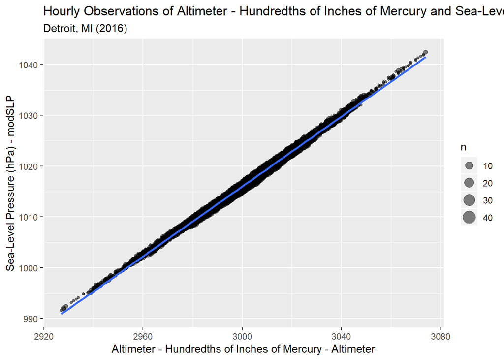

```r
# Example for Detroit 2016 - using Altimeter and modSLP
plotNumCor(kdtw_2016, var1="Altimeter", var2="modSLP", subT="Detroit, MI (2016)", diagnose=TRUE)
```

The function plotFactorNumeric() creates box plots for a numeric variable against a factor variable:

```
##
## Removing 49 records due to NA
```

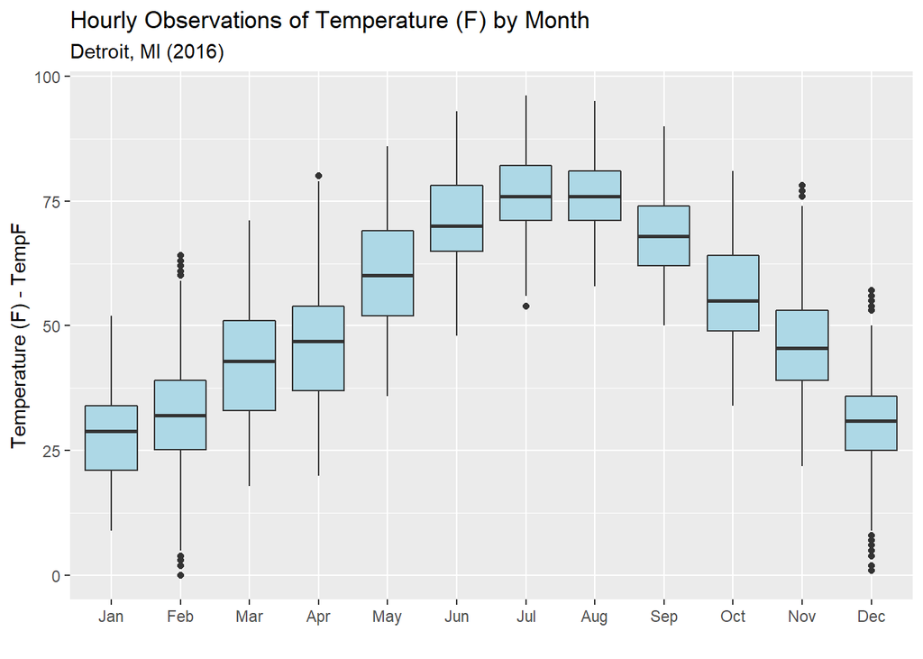

```r
# Updated function for plotting numeric by factor
plotFactorNumeric <- function(met,
                              fctVar,
                              numVar,
                              title=NULL,
                              subT,
                              diagnose=TRUE,
                              showXLabel=TRUE,
                              mapper=varMapper
                              ) {

    # Create the title if not passed
    if (is.null(title)) {
        title <- paste0("Hourly Observations of ", mapper[numVar], " by ", mapper[fctVar])
    }

    nOrig <- nrow(met)
    dat <- met %>%
        filter(!is.na(get(fctVar)), !is.na(get(numVar)))
    if (diagnose) { cat("\nRemoving", nOrig-nrow(dat), "records due to NA\n") }

    p <- dat %>%
        ggplot(aes_string(x=fctVar, y=numVar)) +
        geom_boxplot(fill="lightblue") +
        labs(title=title,
             subtitle=subT,
             x=ifelse(showXLabel, paste0(mapper[fctVar], " - ", fctVar), ""),
             y=paste0(mapper[numVar], " - ", numVar)
             )

    print(p)

}

# Example for Detroit 2016 - using TempF and month
plotFactorNumeric(kdtw_2016,
                  fctVar="month",
                  numVar="TempF",
                  subT="Detroit, MI (2016)",
                  showXLabel=FALSE,
                  diagnose=TRUE
                  )
```

```
##
## Removing 49 records due to NA
```

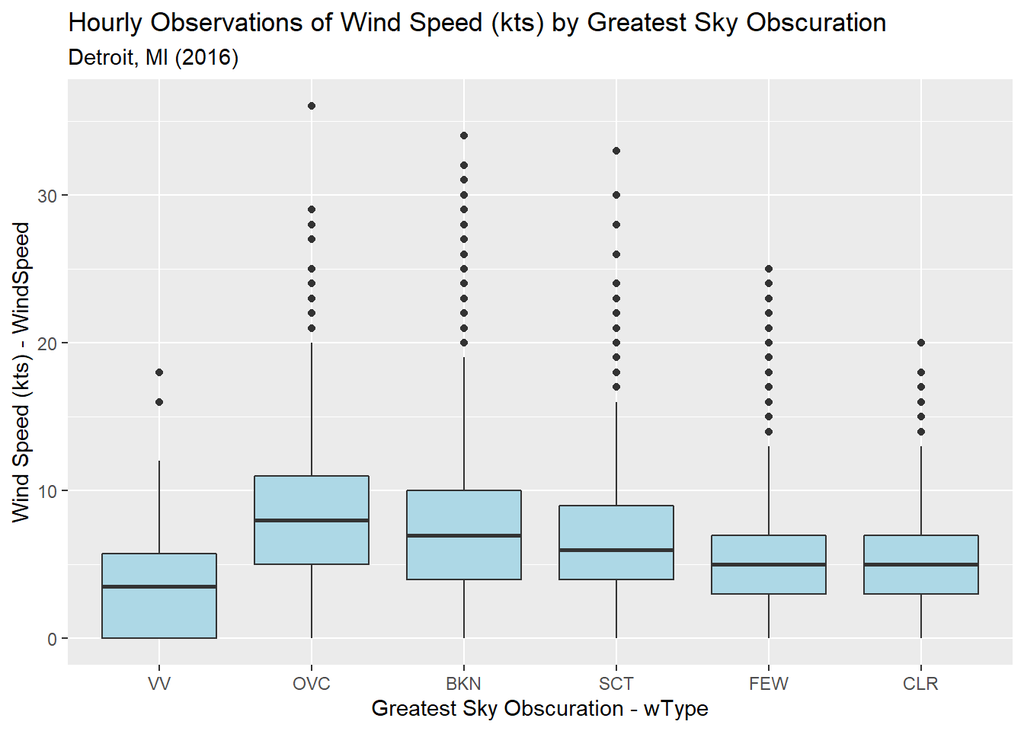

```r
# Example for Detroit 2016 - using WindSpeed and wType
plotFactorNumeric(kdtw_2016,
                  fctVar="wType",
                  numVar="WindSpeed",
                  subT="Detroit, MI (2016)",
                  showXLabel=TRUE,
                  diagnose=TRUE
                  )
```

```
##
## Removing 49 records due to NA
```

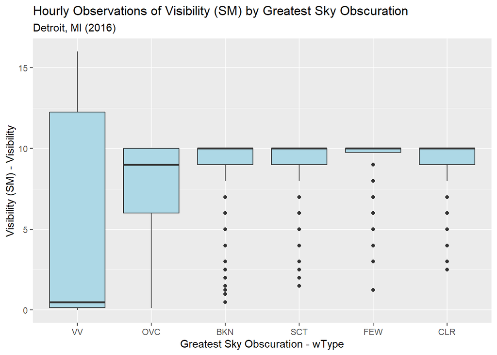

```r
# Example for Detroit 2016 - using Visibility and wType
plotFactorNumeric(kdtw_2016,
                  fctVar="wType",
                  numVar="Visibility",
                  subT="Detroit, MI (2016)",
                  showXLabel=TRUE,
                  diagnose=TRUE
                  )
```

The visibility graph highlights an issue with visibilities when wType is VV:

```r
kdtw_2016 %>%
    filter(wType=="VV") %>%
    count(Visibility)
```

```
## # A tibble: 7 x 2
##   Visibility     n
##        <dbl> <int>
## 1      0         2
## 2      0.125    15
## 3      0.25     15
## 4      0.5       8
## 5      0.75      8
## 6      1         1
## 7     16        17
```

```r
kdtw_2016 %>%
    filter(wType=="VV", Visibility==16) %>%
    pull(origMETAR) %>%
    head(5)
```

```
## [1] "KDTW 280953Z 17004KT 1/16SM R03R/1600V1800FT FG VV002 21/21 A3016 RMK AO2 SFC VIS 1/4 SLP209 T02110211 $"
## [2] "KDTW 091153Z 32003KT 1/16SM R03R/1800V2800FT FG VV001 19/19 A2999 RMK AO2 TWR VIS 1/2 SLP150 70002 T01940194 10222 20194 51009 $"
## [3] "KDTW 070253Z 00000KT 1/16SM R03R/0700V0800FT FG VV001 10/10 A3039 RMK AO2 SLP292 FG AT AP T01000100 53003 $"
## [4] "KDTW 070353Z 00000KT 1/16SM R03R/0800V1000FT FG VV001 10/10 A3039 RMK AO2 SLP293 T01000100 $"
## [5] "KDTW 070453Z 00000KT 1/16SM R03R/0700V1000FT FG VV001 09/09 A3039 RMK AO2 SLP293 T00940094 401890061 $"
```

The functions from the preceding section will need to be updated to extract 1/ddSM as well as 1/dSM, since the routine as-is only looks for d?d/dSM and thus misses the 1/16 SM records.

The function corMETAR() calculates correlations among numeric variables in the METAR data:

```
##
##  *** Correlations use 8769 complete cases (99.4% of 8818 total) ***
##            TempC TempF  DewC  DewF Altimeter modSLP WindSpeed Visibility
## TempC       1.00  1.00  0.92  0.92     -0.17  -0.24     -0.10       0.14
## TempF       1.00  1.00  0.92  0.92     -0.17  -0.24     -0.10       0.14
## DewC        0.92  0.92  1.00  1.00     -0.22  -0.28     -0.18      -0.06
## DewF        0.92  0.92  1.00  1.00     -0.22  -0.28     -0.18      -0.06
## Altimeter  -0.17 -0.17 -0.22 -0.22      1.00   1.00     -0.37       0.17
## modSLP     -0.24 -0.24 -0.28 -0.28      1.00   1.00     -0.35       0.16
## WindSpeed  -0.10 -0.10 -0.18 -0.18     -0.37  -0.35      1.00       0.08
## Visibility  0.14  0.14 -0.06 -0.06      0.17   0.16      0.08       1.00
```

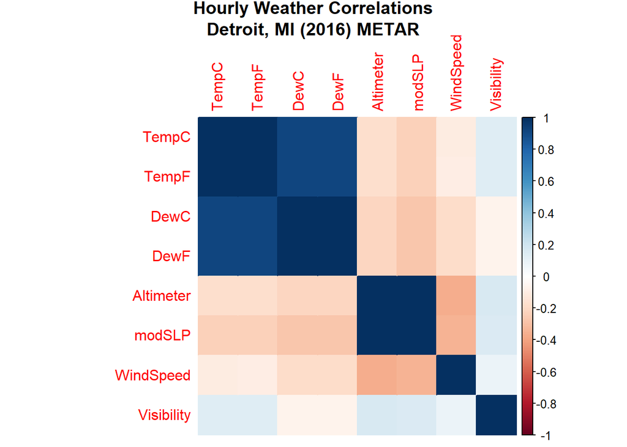

```r
# Function to calculate, display, and plot variable correlations
corMETAR <- function(met, numVars, subT="") {

    # Keep only complete cases and report on data kept
    dfUse <- met %>%
        select_at(vars(all_of(numVars))) %>%
        filter(complete.cases(.))

    nU <- nrow(dfUse)
    nM <- nrow(met)
    myPct <- round(100*nU/nM, 1)
    cat("\n *** Correlations use ", nU, " complete cases (", myPct, "% of ", nM, " total) ***\n", sep="")

    # Create the correlation matrix
    mtxCorr <- dfUse %>%
        cor()

    # Print the correlations
    mtxCorr %>%
        round(2) %>%
        print()

    # Display a heat map
    corrplot::corrplot(mtxCorr,
                       method="color",
                       title=paste0("Hourly Weather Correlations\n", subT),
                       mar=c(0, 0, 2, 0)
                       )
}

# Example for Detroit, MI 2016
coreNum <- c("TempC", "TempF", "DewC", "DewF",
             "Altimeter", "modSLP", "WindSpeed", "Visibility"
             )
corMETAR(kdtw_2016, numVars=coreNum, subT="Detroit, MI (2016) METAR")
```

The function lmMETAR() runs simple linear regression models on the METAR data:

```
##
##  *** Regression call is: modSLP ~ Altimeter ***
##
## Call:
## lm(formula = formula(myChar), data = met)
##
## Residuals:
##      Min       1Q   Median       3Q      Max
## -0.96361 -0.44022 -0.03758  0.40772  1.41448
##
## Coefficients:
##               Estimate Std. Error t value Pr(>|t|)
## (Intercept) -1.644e+01  7.472e-01  -22.01   <2e-16 ***
## Altimeter    3.442e-01  2.488e-04 1383.17   <2e-16 ***
## ---
## Signif. codes:  0 '***' 0.001 '**' 0.01 '*' 0.05 '.' 0.1 ' ' 1
##
## Residual standard error: 0.4961 on 8767 degrees of freedom
##   (49 observations deleted due to missingness)
## Multiple R-squared:  0.9954, Adjusted R-squared:  0.9954
## F-statistic: 1.913e+06 on 1 and 8767 DF,  p-value: < 2.2e-16
```

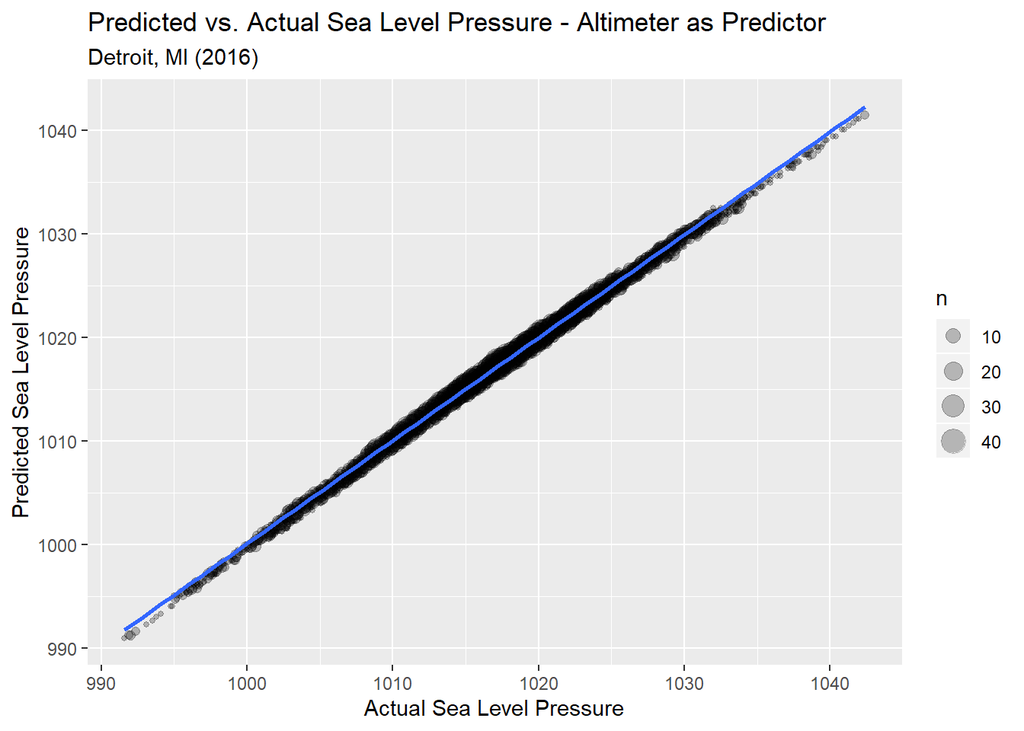

```r
# Function for linear regressions on METAR data
lmMETAR <- function(met,
                    y,
                    x,
                    yName,
                    subT=""
                    ) {

    # Convert to formula
    myChar <- paste0(y, " ~ ", x)
    cat("\n *** Regression call is:", myChar, "***\n")

    # Run regression
    regr <- lm(formula(myChar), data=met)

    # Summarize regression
    print(summary(regr))

    # Predict the new values
    pred <- predict(regr, newdata=met)

    # Plot the predictions
    p <- met %>%
        select_at(vars(all_of(y))) %>%
        mutate(pred=pred) %>%
        group_by_at(vars(all_of(c(y, "pred")))) %>%
        summarize(n=n()) %>%
        ggplot(aes_string(x=y, y="pred")) +
        geom_point(aes(size=n), alpha=0.25) +
        geom_smooth(aes(weight=n), method="lm") +
        labs(title=paste0("Predicted vs. Actual ", yName, " - ", x, " as Predictor"),
             subtitle=subT,
             x=paste0("Actual ", yName),
             y=paste0("Predicted ", yName)
             )
    print(p)

}

# Examples for Detroit, MI 2016
lmMETAR(kdtw_2016, "modSLP", "Altimeter", yName="Sea Level Pressure", subT="Detroit, MI (2016)")
```

```r
lmMETAR(kdtw_2016, "modSLP", "Altimeter + TempF", yName="Sea Level Pressure", subT="Detroit, MI (2016)")
```

```
##
##  *** Regression call is: modSLP ~ Altimeter + TempF ***
##
## Call:
## lm(formula = formula(myChar), data = met)
##
## Residuals:
##      Min       1Q   Median       3Q      Max
## -0.57802 -0.12674  0.00481  0.12820  0.65708
##
## Coefficients:
##               Estimate Std. Error t value Pr(>|t|)
## (Intercept) -3.713e+00  2.803e-01  -13.25   <2e-16 ***
## Altimeter    3.403e-01  9.302e-05 3658.80   <2e-16 ***
## TempF       -2.351e-02  9.941e-05 -236.48   <2e-16 ***
## ---
## Signif. codes:  0 '***' 0.001 '**' 0.01 '*' 0.05 '.' 0.1 ' ' 1
##
## Residual standard error: 0.1826 on 8766 degrees of freedom
##   (49 observations deleted due to missingness)
## Multiple R-squared:  0.9994, Adjusted R-squared:  0.9994
## F-statistic: 7.086e+06 on 2 and 8766 DF,  p-value: < 2.2e-16
```

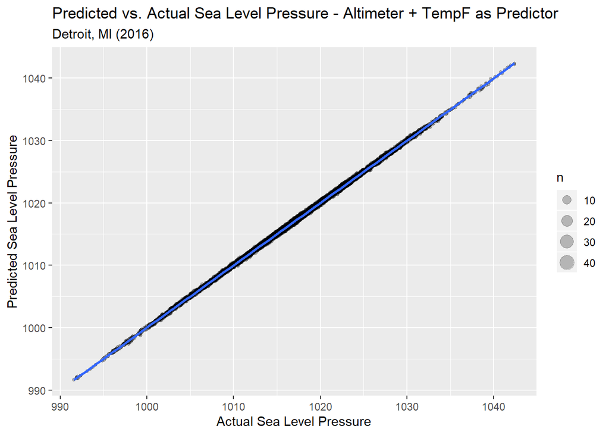

```r
lmMETAR(kdtw_2016, "TempC", "DewC", yName="Temperature (C)", subT="Detroit, MI (2016)")
```

```
##
##  *** Regression call is: TempC ~ DewC ***
##
## Call:
## lm(formula = formula(myChar), data = met)
##
## Residuals:
##    Min     1Q Median     3Q    Max
## -6.174 -3.172 -1.165  2.822 17.828
##
## Coefficients:
##             Estimate Std. Error t value Pr(>|t|)
## (Intercept)  6.17084    0.05373   114.9   <2e-16 ***
## DewC         0.99909    0.00470   212.6   <2e-16 ***
## ---
## Signif. codes:  0 '***' 0.001 '**' 0.01 '*' 0.05 '.' 0.1 ' ' 1
##
## Residual standard error: 4.463 on 8767 degrees of freedom
##   (49 observations deleted due to missingness)
## Multiple R-squared:  0.8375, Adjusted R-squared:  0.8375
## F-statistic: 4.519e+04 on 1 and 8767 DF,  p-value: < 2.2e-16
```

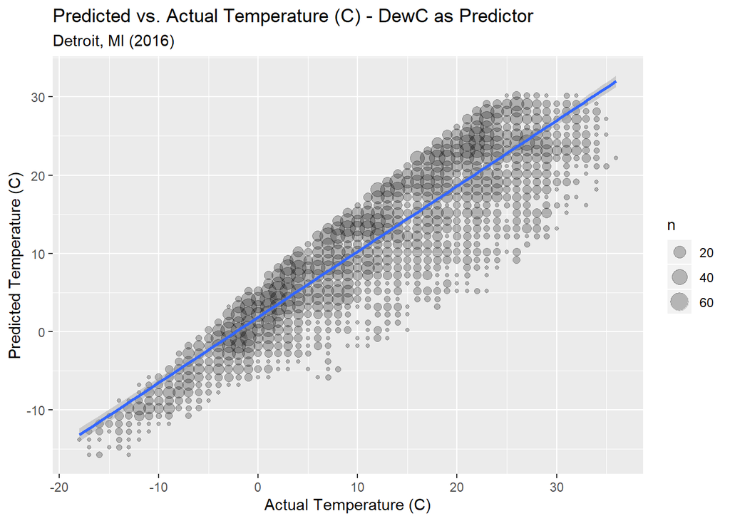

The basicWindPlots() function creates plots for wind speed and direction:

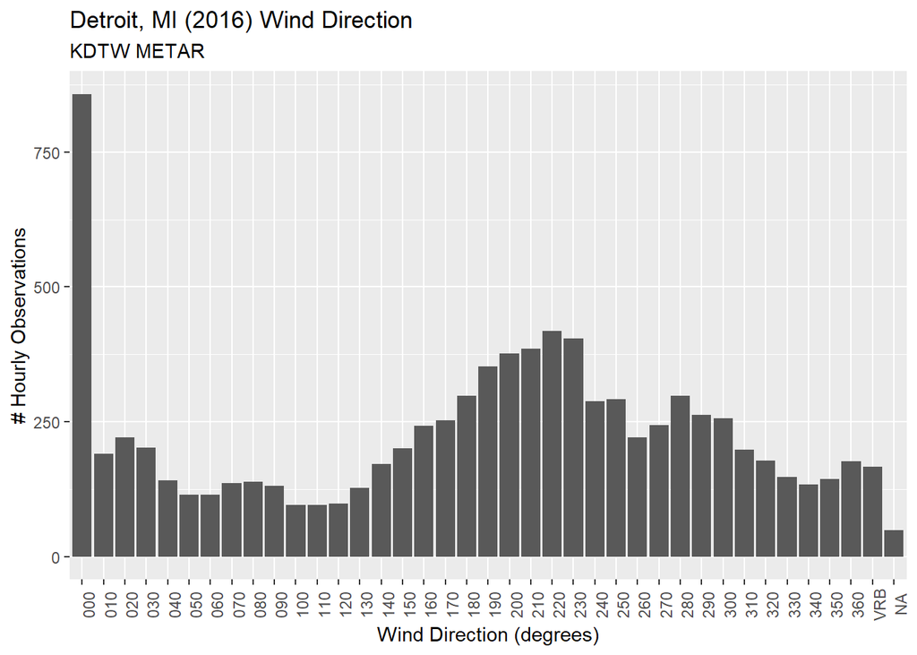

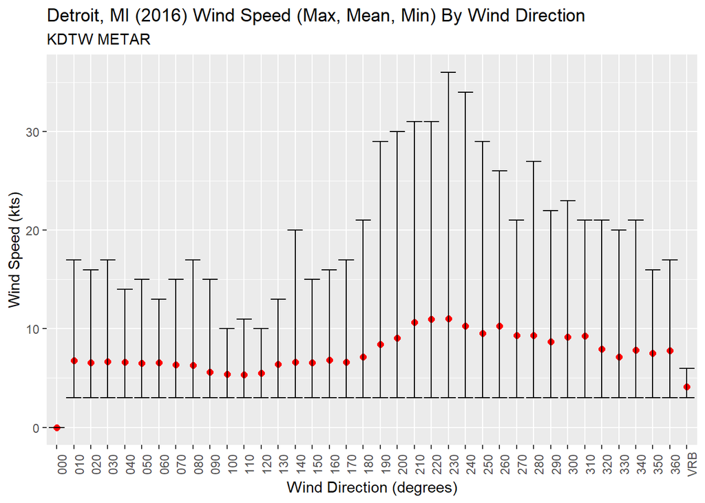

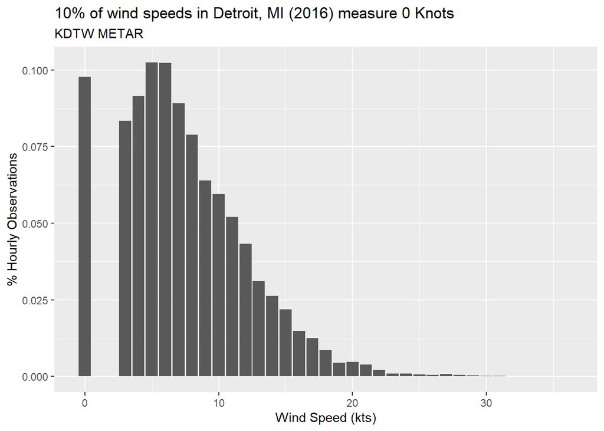

```
##     WindDir      WindSpeed           n
##  Min.   : 10   Min.   : 3.00   Min.   : 1.00
##  1st Qu.:130   1st Qu.: 7.00   1st Qu.: 3.00
##  Median :220   Median :11.00   Median :12.00
##  Mean   :202   Mean   :11.72   Mean   :13.15
##  3rd Qu.:280   3rd Qu.:16.00   3rd Qu.:20.00
##  Max.   :360   Max.   :36.00   Max.   :49.00
```

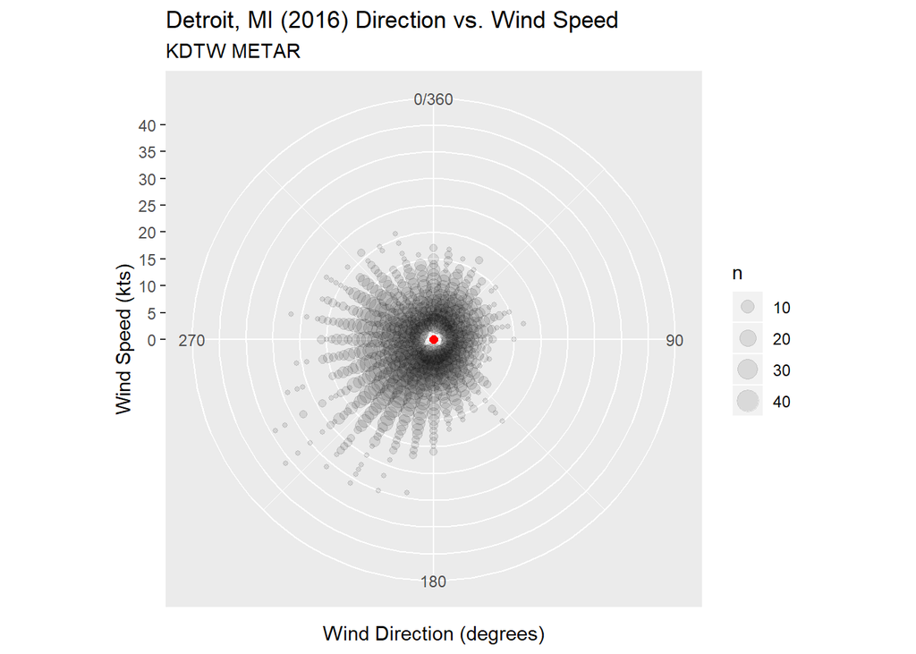

```r
# Generate basic wind plots
basicWindPlots <- function(met,
                           dirVar="WindDir",
                           spdVar="WindSpeed",
                           desc="",
                           gran="",
                           mapper=varMapper
                           ) {

    # Plot for the wind direction
    wDir <- met %>%
        ggplot(aes_string(x=dirVar)) +
        geom_bar() +
        labs(title=paste0(desc, " Wind Direction"), subtitle=gran,
             y="# Hourly Observations", x=mapper[dirVar]
             ) +
        theme(axis.text.x=element_text(angle=90))
    print(wDir)

    # Plot for the minimum, average, and maximum wind speed by wind direction
    # Wind direction 000 is reserved for 0 KT wind, while VRB is reserved for 3-6 KT variable winds
    wSpeedByDir <- met %>%
        filter(!is.na(get(dirVar))) %>%
        group_by_at(vars(all_of(dirVar))) %>%
        summarize(minWind=min(get(spdVar)), meanWind=mean(get(spdVar)), maxWind=max(get(spdVar))) %>%
        ggplot(aes_string(x=dirVar)) +
        geom_point(aes(y=meanWind), color="red", size=2) +
        geom_errorbar(aes(ymin=minWind, ymax=maxWind)) +
        labs(title=paste0(desc, " Wind Speed (Max, Mean, Min) By Wind Direction"),
             subtitle=gran,
             y=mapper[spdVar],
             x=mapper[dirVar]
             ) +
        theme(axis.text.x=element_text(angle=90))
    print(wSpeedByDir)

    # Plot for the wind speed
    pctZero <- sum(pull(met, spdVar)==0, na.rm=TRUE) / nrow(met)
    wSpeed <- met %>%
        filter_at(vars(all_of(spdVar)), all_vars(!is.na(.))) %>%
        ggplot(aes_string(x=spdVar)) +
        geom_bar(aes(y=..count../sum(..count..))) +
        labs(title=paste0(round(100*pctZero), "% of wind speeds in ", desc, " measure 0 Knots"),
             subtitle=gran,
             y="% Hourly Observations",
             x=mapper[spdVar]
             )
    print(wSpeed)

    # Polar plot for wind speed and wind direction
    wData <- met %>%
        filter_at(vars(all_of(dirVar)), all_vars(!is.na(.) & !(. %in% c("000", "VRB")))) %>%
        filter_at(vars(all_of(spdVar)), all_vars(!is.na(.))) %>%
        mutate_at(vars(all_of(dirVar)), as.numeric) %>%
        group_by_at(vars(all_of(c(dirVar, spdVar)))) %>%
        summarize(n=n())
    print(summary(wData))

    wPolarDirSpeed <- wData %>%
        ggplot(aes_string(x=spdVar, y=dirVar)) +
        geom_point(alpha=0.1, aes(size=n)) +
        coord_polar(theta="y") +
        labs(title=paste0(desc, " Direction vs. Wind Speed"),
             subtitle=gran,
             x=mapper[spdVar],
             y=mapper[dirVar]
             ) +
        scale_y_continuous(limits=c(0, 360), breaks=c(0, 90, 180, 270, 360)) +
        scale_x_continuous(limits=c(0, 40), breaks=c(0, 5, 10, 15, 20, 25, 30, 35, 40)) +
        geom_point(aes(x=0, y=0), color="red", size=2)
    print(wPolarDirSpeed)

}

# Example for Detroit, MI 2016
basicWindPlots(kdtw_2016, desc="Detroit, MI (2016)", gran="KDTW METAR")
```

The getWindDirGroup() function maps wind direction to a category such as NNE. Because the METAR data are recorded in units of 10 degrees, either 4 groupings (90 degrees each) or 12 groupings (30 degrees each) are preferred, so that each category has the same underlying number of buckets:

```r
# Extract the wind direction data from a processed METAR file
getWindDirGroup <- function(met, src) {

    # Use the fullMETAR data and extract WindDir, WindSpeed, month
    windPlotData <- met %>%
        select(WindDir, WindSpeed, month) %>%
        mutate(windDirGroup=factor(case_when(WindSpeed==0 ~ "No Wind",
                                             WindDir=="VRB" ~ "Variable",
                                             WindDir %in% c("350", "360", "010") ~ "N",
                                             WindDir %in% c("020", "030", "040") ~ "NNE",
                                             WindDir %in% c("050", "060", "070") ~ "ENE",
                                             WindDir %in% c("080", "090", "100") ~ "E",
                                             WindDir %in% c("110", "120", "130") ~ "ESE",
                                             WindDir %in% c("140", "150", "160") ~ "SSE",
                                             WindDir %in% c("170", "180", "190") ~ "S",
                                             WindDir %in% c("200", "210", "220") ~ "SSW",
                                             WindDir %in% c("230", "240", "250") ~ "WSW",
                                             WindDir %in% c("260", "270", "280") ~ "W",
                                             WindDir %in% c("290", "300", "310") ~ "WNW",
                                             WindDir %in% c("320", "330", "340") ~ "NNW",
                                             TRUE ~ "Error"
                                             ),
                                   levels=c("No Wind", "Variable", "Error",
                                            "N", "NNE", "ENE",
                                            "E", "ESE", "SSE",
                                            "S", "SSW", "WSW",
                                            "W", "WNW", "NNW"
                                            )
                                   )
               )

    # Rempve the errors and calculate percentages by month for the remainder
    processedWindData <- windPlotData %>%
        filter(windDirGroup != "Error") %>%
        group_by(month, windDirGroup) %>%
        summarize(n=n()) %>%
        ungroup() %>%
        group_by(month) %>%
        mutate(pct=n/sum(n)) %>%
        ungroup() %>%
        mutate(src=src)

    processedWindData

}
```

The function conslidatePlotWind() then calls getWindDirGroup() for any number of files:

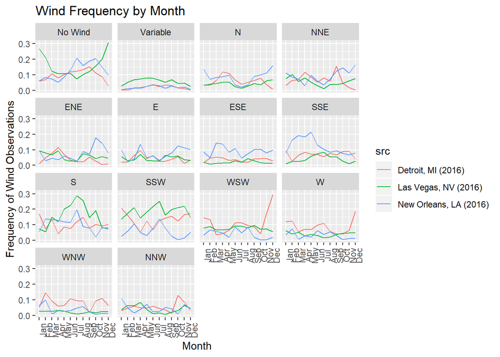

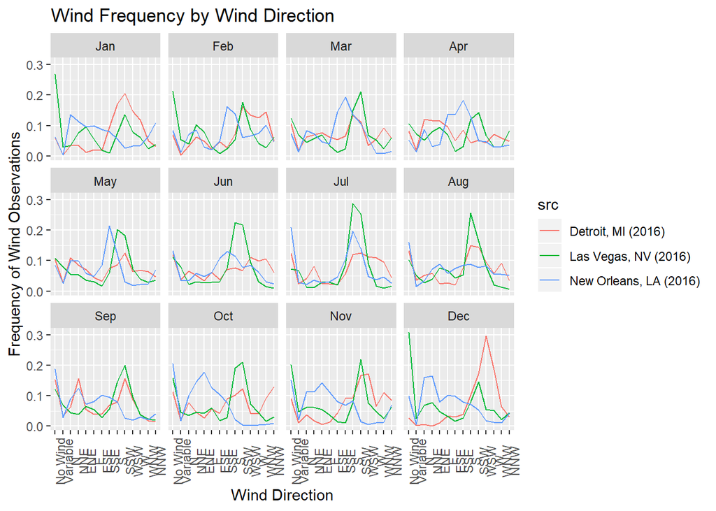

```
## # A tibble: 504 x 5
##    month windDirGroup     n     pct src
##    <fct> <fct>        <int>   <dbl> <chr>
##  1 Jan   No Wind         46 0.0600  Detroit, MI (2016)
##  2 Jan   Variable         3 0.00391 Detroit, MI (2016)
##  3 Jan   N               26 0.0339  Detroit, MI (2016)
##  4 Jan   NNE             26 0.0339  Detroit, MI (2016)
##  5 Jan   ENE              9 0.0117  Detroit, MI (2016)
##  6 Jan   E               16 0.0209  Detroit, MI (2016)
##  7 Jan   ESE             14 0.0183  Detroit, MI (2016)
##  8 Jan   SSE             72 0.0939  Detroit, MI (2016)
##  9 Jan   S              131 0.171   Detroit, MI (2016)
## 10 Jan   SSW            158 0.206   Detroit, MI (2016)
## # ... with 494 more rows
```

```r
# Consolidate and plot wind data
consolidatePlotWind <- function(files, names) {

    consFun <- function(x, y) { getWindDirGroup(met=x, src=y) }
    boundByRows <- map2_dfr(.x=files, .y=names, .f=consFun)

    # Show frequency by month for each city, faceted by wind direction
    p1 <- boundByRows %>%
        ggplot(aes(x=month, y=pct, color=src)) +
        geom_line(aes(group=src)) +
        facet_wrap(~windDirGroup) +
        labs(title="Wind Frequency by Month",
             x="Month",
             y="Frequency of Wind Observations"
             ) +
        theme(axis.text.x=element_text(angle=90))
    print(p1)

    # Show frequency by wind direction for each city, faceted by month
    p2 <- boundByRows %>%
        ggplot(aes(x=windDirGroup, y=pct, color=src)) +
        geom_line(aes(group=src)) +
        facet_wrap(~month) +
        labs(title="Wind Frequency by Wind Direction",
             x="Wind Direction",
             y="Frequency of Wind Observations"
             ) +
        theme(axis.text.x=element_text(angle=90))
    print(p2)

    boundByRows

}

# Load the Las Vegas data and New Orleans data for comparison
kmsy_2016 <- readRDS("./RInputFiles/ProcessedMETAR/metar_kmsy_2016.rds")
klas_2016 <- readRDS("./RInputFiles/ProcessedMETAR/metar_klas_2016.rds")

# Run wind by month comparisons for Detroit, Las Vegas, New Orleans
consolidatePlotWind(files=list(kdtw_2016, klas_2016, kmsy_2016),
                    names=c("Detroit, MI (2016)", "Las Vegas, NV (2016)", "New Orleans, LA (2016)")
                    )
```